# Course Notes 7

January 12, 2016

## Markdown

## Mark-up languages

In Word, you can add formatting using buttons and keyboard shortcuts (e.g., "Ctrl-B" for bold). The file saves the words you type. It also saves the formatting, but you see the final output, rather than the formatting markup, when you edit the file.

In mark-up languages, you markup the document directly to show what formatting the final version should have (e.g., `**bold**` for **bold**).

## Mark-up languages

Examples of mark-up languages include:

- markdown
- html
- LaTex

## Mark-up languages

For example, here's some marked-up html code from CSU's front page:

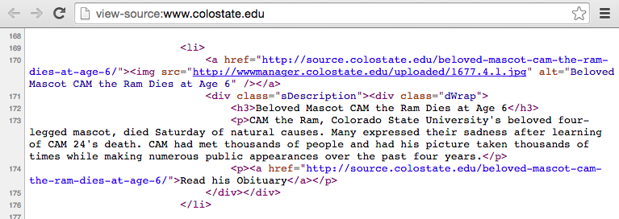

## Mark-up languages

And here's how it looks when it's rendered by a web browser:

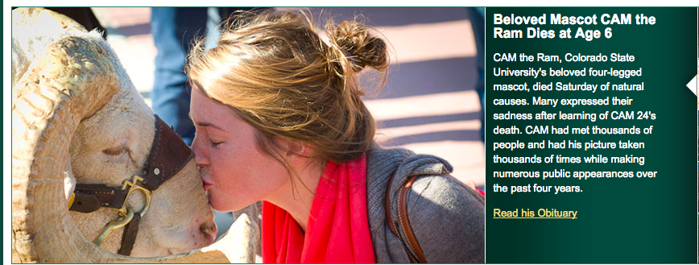

## Markdown conventions

| Code | Rendering |
| --- | --- |
| `**text**` | **text** (bold) |
| `*text*` | *text* (italics) |
| `text` | `text` (computer code) |
| `[text](www.google.com)` | text (link) |
| `# text` | First-level header |
| `## text` | Second-level header |

## Markdown conventions

For more Markdown conventions, you can click on the question mark on the panel of an .Rmd script and choose "Markdown Quick Reference".

Some other simple things you can do:

- Lists (ordered or bulleted)
- Equations
- Tables
- Outside figures

## `knitr` and RMarkdown

## Literate programming with `knitr`

[figure not shown]

(Source: RMarkdown Cheatsheet, RStudio)

## Basics

- To open a new RMarkdown file, go to "File" -> "New File" -> "RMarkdown…" -> for now, chose a "Document" in "HTML" format.
- The file extension for RMarkdown files is ".Rmd"
- Once you "knit", there will be an HTML file with the output in the same directory where you've saved your .Rmd file.
- Write everything besides code in markdown syntax.

## More basics

- All the code in the file will run "from scratch"– as if you just opened a new R session.
- The code will run using the directory where you saved the .Rmd as the working directory.

## Chunk syntax

To include R code in an RMarkdown document, separate off the code chunk using the following syntax:

````
```{r}
my_vec <- 1:10
```
````

## Naming chunks

You can specify a name for each chunk, if you'd like, by including it after "r" when you begin your chunk:

````
```{r load_nepali}
library(faraway)
data(nepali)
```
````

If you name chunks, it will be easier to find any errors. Any chunks you don't name are given numbers by `knitr`.

Chunk names must be unique.

## Chunk options

You can add options when you start a chunk.

TRUE / FALSE options you might want to use include:

| Option | Action |
| --- | --- |
| `echo` | Print out the R code? |
| `eval` | Run the R code? |
| `messages` | Print out messages? |
| `warnings` | Print out warnings? |
| `include` | If FALSE, run, but don't print code or results |

## Chunk options

Other options you might want to include:

| Option | Action |
| --- | --- |
| `results` | How to print results (e.g., `hide` runs the code, but doesn't print the results) |
| `fig.width` | Width to print your figure, in inches (e.g., `fig.width = 4`) |
| `fig.height` | Height to print your figure |

## Chunk options

Add these options in the opening brackets and separate multiple ones with commas:

````
```{r  messages = FALSE, echo = FALSE}
nepali[1, 1:3]
```
````

There are other options as well, but we'll save discussion of those for later in the course.

## Global options

You can set "global" options at the beginning of the document. This will create new defaults for all of the chunks in the document.

````
```{r global_options}
knitr::opts_chunk$set(echo = FALSE, message = FALSE,
  warning = FALSE, fig.path = `Figs/`)
```
````

## Global options

Chunk options take precedence over global options.

For example:

````
```{r global_options}
knitr::opts_chunk$set(echo = FALSE, message = FALSE,
  warning = FALSE, fig.path = `Figs/`)
```
````

````
```{r echo = TRUE}
head(nepali, 1)
```
````

## Inline code

You can also include R output directly in your text ("inline"):

> There are`` `r nrow(nepali)` `` observations in the `nepali` dataset. The average age is `` `r mean(nepali$age, na.rm = TRUE)` `` months.

Compiled, this gives:

> There are 1000 observations in the `nepali` dataset. The average age is 37.662 months.

## Working with Rmd files

## Running code

You can run code in chunks just like you can run code from a script (Ctrl-Return or the "Run" button).

Also, you can run all the code in a chunk (or all the code in all chunks) using the different options under the "Chunks" button. These all also have keyboard shortcuts.

## Compiling to other formats

You can compile RMarkdown documents to other formats:

- Word
- Pdf (requires that you've installed "Tex" on your computer.)
- Slides (ioslides)

Click the button to the right of "Knit HTML" to see different options for rendering.

## References to find out more

Two good how-to books on reproducible research in R:

- *Reproducible Research with R and RStudio*, Christopher Gandrud
- *Dynamic Documents with R and knitr*, Yihui Xie